# Assignment 8: Semantic Distance

Amaka Peace Onebunne

April 2026

# R package

[Link to our R package here](https://github.com/Reilly-ConceptsCognitionLab/SemanticDistance)

# Step 1: Load Data

```r
#Getting dataset, get a peak first
ls("package:SemanticDistance")
```

```
##  [1] "clean_dialogue"          "clean_monologue_or_list"
##  [3] "clean_paired_cols"       "Dialogue_Typical"
##  [5] "dist_anchor"             "dist_dialogue"
##  [7] "dist_ngram2ngram"        "dist_ngram2word"
##  [9] "dist_paired_cols"        "glowca_25"
## [11] "Grandfather_Passage"     "Monologue_Typical"
## [13] "SD15_2025_complete"      "Temple_stops25"
## [15] "Unordered_List"          "Word_Pairs"
## [17] "wordlist_to_network"
```

```r
# Load lookup database (inside the package)
data("Word_Pairs")
cat("Word_Pairs dimensions:", dim(Word_Pairs), "\n")
```

```
## Word_Pairs dimensions: 27 2
```

```r
head(Word_Pairs)
```

| word1 | word2 |
| --- | --- |
| Dog | trumpet |
| the | BANANA |
| rat | astronaut |
| *&^% | lizard |
| bird | bird |
| shark | shark |

```r
# Load the SD15
data("SD15_2025_complete")
cat("SD15 dimensions:", dim(SD15_2025_complete), "\n")
```

```
## SD15 dimensions: 25050 16
```

```r
head(SD15_2025_complete)
```

| word | Param_auditory_z | Param_gustatory_z | Param_haptic_z | Param_interoceptive_z | Param_visual_z | Param_olfactory_z | Param_handarm_z | Param_excitement_z | Param_surprised_z | Param_fear_z | Param_anger_z | Param_disgust_z | Param_sadness_z | Param_happiness_z | Param_contempt_z |
| --- | --- | --- | --- | --- | --- | --- | --- | --- | --- | --- | --- | --- | --- | --- | --- |
| a | 0.70679673 | -0.4647709 | -0.6909038 | -1.1723518 | -0.51925761 | -0.6298500 | -1.2020258 | -0.3667109 | -0.8584641 | -0.1074207 | 0.1797387 | -0.7048057 | 0.0969251 | 0.4821942 | -0.3517269 |
| aardvark | 0.11203503 | 0.3424060 | 0.5897719 | -1.1013673 | 1.36052207 | 1.3894667 | -0.8173439 | 0.1649748 | -0.6034863 | 0.2862406 | 0.2632453 | 0.1430684 | -1.0727042 | -0.3795972 | -0.9333697 |
| aback | -0.22192207 | -0.3803603 | -0.8348253 | 0.3642540 | -0.08161231 | -0.6298500 | -1.5959771 | 0.3935996 | 5.4535374 | 1.2495263 | 0.2952752 | 0.0790120 | 0.6901990 | -0.7637570 | 0.4993708 |
| abacus | 0.04194527 | -0.2256074 | 2.8346711 | -0.8568651 | 1.16045195 | -0.4503552 | 1.1326543 | -0.5166463 | -0.7010544 | -0.8101456 | -0.5866915 | -0.5219537 | -0.5110114 | 0.4832214 | -0.9939080 |
| abandoned | -0.07019835 | -0.4647709 | -1.0901858 | 0.7205683 | -0.13230881 | -0.6298500 | -0.4348574 | -1.8905220 | 0.4164249 | 1.8022313 | 2.0786553 | 1.9855642 | 2.7418437 | -2.0908542 | 1.8893782 |
| abandonment | 0.62509209 | -0.3691055 | 0.1348453 | 2.1591877 | 0.11393133 | -0.5221531 | -1.1232355 | -2.1053230 | -0.7374798 | 1.8642696 | 2.1941918 | 1.9075318 | 2.9290746 | -1.7827047 | 2.7654034 |

```r
# Pull all unique words that appear in Word_Pairs
all_words <- unique(c(Word_Pairs$word1, Word_Pairs$word2))
all_words  <- all_words[!is.na(all_words) & nchar(trimws(all_words)) > 0]
cat("Total unique words available:", length(all_words), "\n")
```

```
## Total unique words available: 47
```

```r
# Randomly sample 500 unique, non-identical, deduplicated pairs
set.seed(42)
N <- 500

# Oversample to account for losses from deduplication and identical-pair removal
idx1 <- sample(length(all_words), N * 1.3, replace = TRUE)
idx2 <- sample(length(all_words), N * 1.3, replace = TRUE)


pairs_raw <- data.frame(
  word1 = all_words[idx1],
  word2 = all_words[idx2],
  stringsAsFactors = FALSE
) %>%
  # Remove identical pairs (dog–dog)
  filter(word1 != word2) %>%
  # Deduplicate: treat (apple, dog) == (dog, apple)
  rowwise() %>%
  mutate(
    w_a = min(word1, word2),
    w_b = max(word1, word2)
  ) %>%
  ungroup() %>%
  distinct(w_a, w_b) %>%
  rename(word1 = w_a, word2 = w_b) %>%
  slice_head(n = N)

cat("Final unique pair count:", nrow(pairs_raw), "\n")
```

```
## Final unique pair count: 469
```

```r
head(pairs_raw)
```

| word1 | word2 |
| --- | --- |
| animal | rock |
| Dog | milk |
| astronaut | butter |
| fur | sheet |
| pencil | snail |
| BANANA | lobster |

# Step 2: Clean Pairs & Compute GloVe Embedding Distances

```r
# Clean using SemanticDistance — lemmatize=FALSE since words are already canonical
pairs_clean <- clean_paired_cols(
  dat      = pairs_raw,
  wordcol1 = "word1",
  wordcol2 = "word2",
  lemmatize = FALSE
)

cat("Cleaned pair count:", nrow(pairs_clean), "\n")
```

```
## Cleaned pair count: 414
```

```r
head(pairs_clean)
```

| id_row_orig | word1_clean | word2_clean | word1 | word2 |
| --- | --- | --- | --- | --- |
| 1 | animal | rock | animal | rock |
| 2 | dog | milk | Dog | milk |
| 3 | astronaut | butter | astronaut | butter |
| 4 | fur | sheet | fur | sheet |
| 5 | pencil | snail | pencil | snail |
| 6 | banana | lobster | BANANA | lobster |

```r
# Compute GloVe cosine distances for all 500 pairs

cat("Computing GloVe embedding distances...\n")
```

```
## Computing GloVe embedding distances...
```

```r
t0 <- Sys.time()

embedding_dist <- dist_paired_cols(pairs_clean)

cat("Done in", round(difftime(Sys.time(), t0, units = "mins"), 2), "min\n")
```

```
## Done in 0.02 min
```

```r
cat("Columns returned:", colnames(embedding_dist), "\n")
```

```
## Columns returned: id_row_orig word1_clean word2_clean word1 word2 CosDist_SD15 CosDist_GLO
```

```r
head(embedding_dist)
```

| id_row_orig | word1_clean | word2_clean | word1 | word2 | CosDist_SD15 | CosDist_GLO |
| --- | --- | --- | --- | --- | --- | --- |
| 1 | animal | rock | animal | rock | 0.29 | 0.66 |
| 2 | dog | milk | Dog | milk | 0.71 | 0.69 |
| 3 | astronaut | butter | astronaut | butter | 1.06 | 1.10 |
| 4 | fur | sheet | fur | sheet | 0.13 | 0.76 |
| 5 | pencil | snail | pencil | snail | 0.88 | 0.99 |
| 6 | banana | lobster | BANANA | lobster | 0.06 | 0.82 |

# Step 3: Compute SD15 Experiential Distances

```r
# Join SD15 norms onto word1 and word2 separately, then compute cosine distance
# between the two experiential rating vectors row-by-row

# Identify the word column name in SD15_2025_complete
# SD15 feature columns — everything except the word column
sd15_features <- colnames(SD15_2025_complete)[colnames(SD15_2025_complete) != "word"]
cat("SD15 features:", sd15_features, "\n")
```

```
## SD15 features: Param_auditory_z Param_gustatory_z Param_haptic_z Param_interoceptive_z Param_visual_z Param_olfactory_z Param_handarm_z Param_excitement_z Param_surprised_z Param_fear_z Param_anger_z Param_disgust_z Param_sadness_z Param_happiness_z Param_contempt_z
```

```r
# Join SD15 ratings onto word1, prefix feature cols "w1_"
w1 <- pairs_clean %>%
  left_join(SD15_2025_complete, by = c("word1" = "word")) %>%
  rename_with(~ paste0("w1_", .), all_of(sd15_features))

# Join SD15 ratings onto word2, prefix feature cols "w2_"
w2 <- pairs_clean %>%
  left_join(SD15_2025_complete, by = c("word2" = "word")) %>%
  rename_with(~ paste0("w2_", .), all_of(sd15_features))

# Merge — keep only pairs where BOTH words have SD15 data
combined_sd <- w1 %>%
  inner_join(w2, by = c("word1", "word2")) %>%
  drop_na()

cat("Pairs with complete SD15 data:", nrow(combined_sd), "\n")
```

```
## Pairs with complete SD15 data: 365
```

```r
# Define cosine distance helper (bounded 0-2)
# Cosine distance: 0 = identical, up to 2 = maximally distant
cosine_dist_safe <- function(a, b) {
  a <- as.numeric(a)
  b <- as.numeric(b)
  if (any(is.na(a)) || any(is.na(b))) return(NA_real_)
  denom <- sqrt(sum(a^2)) * sqrt(sum(b^2))
  if (denom == 0) return(NA_real_)
  1 - (sum(a * b) / denom)
}       # cosine similarity (-1 to 1)


# Apply row-wise — may take a moment
cat("Computing SD15 cosine distances...\n")
```

```
## Computing SD15 cosine distances...
```

```r
t1 <- Sys.time()

w1_cols <- paste0("w1_", sd15_features)
w2_cols <- paste0("w2_", sd15_features)

experiential_dist <- combined_sd %>%
  select(word1, word2, all_of(w1_cols), all_of(w2_cols)) %>%
  rowwise() %>%
  mutate(
    sd15_distance = cosine_dist_safe(
      c_across(all_of(w1_cols)),
      c_across(all_of(w2_cols))
    )
  ) %>%
  ungroup() %>%
  select(word1, word2, sd15_distance) %>%
  drop_na(sd15_distance)

cat("Done in", round(difftime(Sys.time(), t1, units = "mins"), 2), "min\n")
```

```
## Done in 0.01 min
```

```r
cat("Pairs with valid SD15 distance:", nrow(experiential_dist), "\n")
```

```
## Pairs with valid SD15 distance: 365
```

```r
head(experiential_dist)
```

| word1 | word2 | sd15_distance |
| --- | --- | --- |
| animal | rock | 0.29 |
| astronaut | butter | 1.06 |
| fur | sheet | 0.13 |
| pencil | snail | 0.88 |
| garlic | whale | 0.96 |
| octopus | sheet | 0.68 |

```r
# Identify the GloVe distance column
glove_col <- colnames(embedding_dist)[
  grep("(?i)glove|embed|cosine|dist", colnames(embedding_dist))
]
glove_col <- glove_col[!glove_col %in% c("word1", "word2")][1]
cat("GloVe distance column:", glove_col, "\n")
```

```
## GloVe distance column: CosDist_SD15
```

```r
# Merge GloVe + SD15 into one analysis dataframe
all_dists <- embedding_dist %>%
  select(word1, word2, glove_distance = CosDist_GLO) %>%
  inner_join(experiential_dist, by = c("word1", "word2")) %>%
  drop_na()

cat("Final merged pair count:", nrow(all_dists), "\n")
```

```
## Final merged pair count: 365
```

```r
# Sanity check — should NOT be 1.0 if SD15 is now independent of GloVe
cat("Sanity check correlation:",
    round(cor(all_dists$glove_distance, all_dists$sd15_distance,
              use = "complete.obs"), 3), "\n")
```

```
## Sanity check correlation: 0.342
```

```r
head(all_dists)
```

| word1 | word2 | glove_distance | sd15_distance |
| --- | --- | --- | --- |
| animal | rock | 0.66 | 0.29 |
| astronaut | butter | 1.10 | 1.06 |
| fur | sheet | 0.76 | 0.13 |
| pencil | snail | 0.99 | 0.88 |
| garlic | whale | 0.90 | 0.96 |
| octopus | sheet | 0.92 | 0.68 |

# Step 4: Distributions: GloVe vs. SD15

```r
# Descriptive statistics for each norm type
summary_tbl <- all_dists %>%
  summarise(
    across(
      c(glove_distance, sd15_distance),
      list(
        N        = ~ sum(!is.na(.)),
        Mean     = ~ mean(., na.rm = TRUE),
        SD       = ~ sd(., na.rm = TRUE),
        Median   = ~ median(., na.rm = TRUE),
        Min      = ~ min(., na.rm = TRUE),
        Max      = ~ max(., na.rm = TRUE),
        Skewness = ~ psych::skew(., na.rm = TRUE)
      ),
      .names = "{.col}__{.fn}"
    )
  ) %>%
  pivot_longer(everything(),
               names_to  = c("Metric", "Stat"),
               names_sep = "__") %>%
  pivot_wider(names_from = Stat, values_from = value)

knitr::kable(summary_tbl, digits = 3, format = "pipe",
             caption = "Descriptive Statistics: GloVe vs. SD15 Cosine Distances")
```

Descriptive Statistics: GloVe vs. SD15 Cosine Distances

| Metric | N | Mean | SD | Median | Min | Max | Skewness |
| --- | --- | --- | --- | --- | --- | --- | --- |
| glove_distance | 365 | 0.806 | 0.141 | 0.832 | 0.239 | 1.103 | -1.000 |
| sd15_distance | 365 | 0.726 | 0.315 | 0.762 | 0.035 | 1.628 | -0.039 |

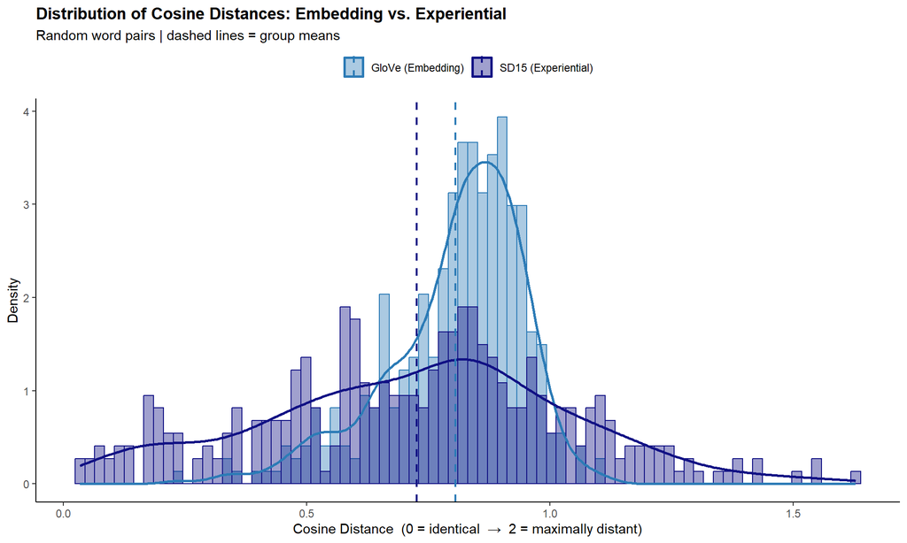

```r
# Long format for ggplot
dist_long <- all_dists %>%
  pivot_longer(
    cols      = c(glove_distance, sd15_distance),
    names_to  = "norm_type",
    values_to = "cosine_distance"
  ) %>%
  mutate(norm_type = recode(norm_type,
    "glove_distance" = "GloVe (Embedding)",
    "sd15_distance"  = "SD15 (Experiential)"
  ))

means_df <- dist_long %>%
  group_by(norm_type) %>%
  summarise(mean_dist = mean(cosine_distance, na.rm = TRUE))

pal <- c("GloVe (Embedding)" = "#2C7BB6", "SD15 (Experiential)" = "#111184")


# Overlapping density histograms
ggplot(dist_long, aes(x = cosine_distance, fill = norm_type, colour = norm_type)) +
  geom_histogram(aes(y = after_stat(density)),
                 bins = 80, alpha = 0.40, position = "identity") +
  geom_density(linewidth = 0.9, alpha = 0) +
  geom_vline(data = means_df,
             aes(xintercept = mean_dist, colour = norm_type),
             linetype = "dashed", linewidth = 0.85) +
  scale_fill_manual(values = pal) +
  scale_colour_manual(values = pal) +
  labs(
    title    = "Distribution of Cosine Distances: Embedding vs. Experiential",
    subtitle = "Random word pairs | dashed lines = group means",
    x        = "Cosine Distance  (0 = identical  →  2 = maximally distant)",
    y        = "Density",
    fill     = NULL, colour = NULL
  ) +
  jamie.theme +
  theme(legend.position = "top",
        plot.title = element_text(face = "bold", size = 13))
```

# Step 5: Correlation Between GloVe & SD15

```r
r_p <- cor(all_dists$glove_distance, all_dists$sd15_distance,
           method = "pearson",  use = "complete.obs")
r_s <- cor(all_dists$glove_distance, all_dists$sd15_distance,
           method = "spearman", use = "complete.obs")

cat(sprintf("Pearson r  = %.3f\n", r_p))
```

```
## Pearson r  = 0.342
```

```r
cat(sprintf("Spearman ρ = %.3f\n", r_s))
```

```
## Spearman ρ = 0.346
```

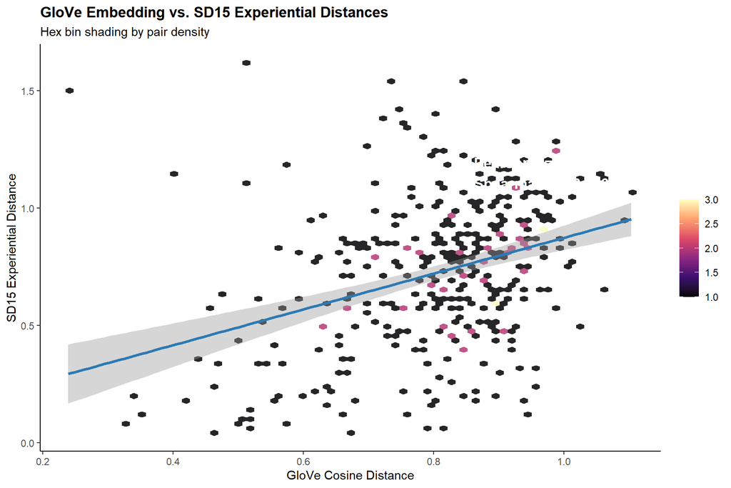

```r
# Hex-bin scatter (efficient for large N)

set.seed(1)
plot_sub <- all_dists %>% slice_sample(n = min(50000, nrow(all_dists)))

ggplot(plot_sub, aes(x = glove_distance, y = sd15_distance)) +
  geom_hex(bins = 70, alpha = 0.85) +
  scale_fill_viridis_c(option = "magma", name = "Count") +
  geom_smooth(method = "lm", colour = "#2C7BB6",
              linewidth = 1.1, se = TRUE) +
  ggplot2::annotate("text",
           x     = quantile(plot_sub$glove_distance, 0.60, na.rm = TRUE),
           y     = quantile(plot_sub$sd15_distance,  0.92, na.rm = TRUE),
           label = sprintf("Pearson r = %.3f\nSpearman ρ = %.3f", r_p, r_s),
           size  = 4.5, hjust = 0, fontface = "bold", colour = "white") +
  labs(
    title    = "GloVe Embedding vs. SD15 Experiential Distances",
    subtitle = "Hex bin shading by pair density",
    x        = "GloVe Cosine Distance",
    y        = "SD15 Experiential Distance"
  ) +
  jamie.theme +
  theme(plot.title = element_text(face = "bold", size = 13))
```

```r
# Top 20 pairs where GloVe & SD15 disagree most
lm_fit <- lm(sd15_distance ~ glove_distance, data = all_dists)
all_dists$residual <- residuals(lm_fit)

top_diverge <- all_dists %>%
  arrange(desc(abs(residual))) %>%
  slice_head(n = 20) %>%
  select(word1, word2, glove_distance, sd15_distance, residual)

knitr::kable(top_diverge, digits = 3, format = "pipe",
             caption = "Top 20 word pairs where GloVe & SD15 distances diverge most")
```

Top 20 word pairs where GloVe & SD15 distances diverge most

| word1 | word2 | glove_distance | sd15_distance | residual |
| --- | --- | --- | --- | --- |
| the | you | 0.239 | 1.503 | 1.209 |
| bed | the | 0.513 | 1.628 | 1.125 |
| rat | water | 0.735 | 1.539 | 0.867 |
| badger | pancake | 0.849 | 1.546 | 0.787 |
| fur | the | 0.746 | 1.419 | 0.739 |
| the | water | 0.397 | 1.147 | 0.733 |
| piano | the | 0.723 | 1.394 | 0.731 |
| lobster | soda | 0.941 | 0.115 | -0.714 |
| shark | water | 0.748 | 1.370 | 0.689 |
| garlic | squid | 0.812 | 0.063 | -0.668 |
| milk | rat | 0.803 | 1.390 | 0.667 |
| pencil | the | 0.764 | 1.351 | 0.657 |
| soda | squid | 0.940 | 0.183 | -0.646 |
| milk | pancake | 0.789 | 0.072 | -0.641 |
| badger | milk | 0.891 | 1.425 | 0.634 |
| bird | the | 0.577 | 1.183 | 0.631 |
| rat | the | 0.696 | 1.265 | 0.623 |
| pancake | squid | 0.961 | 0.242 | -0.602 |
| fork | pencil | 0.868 | 0.174 | -0.600 |
| garlic | pancake | 0.893 | 0.193 | -0.600 |

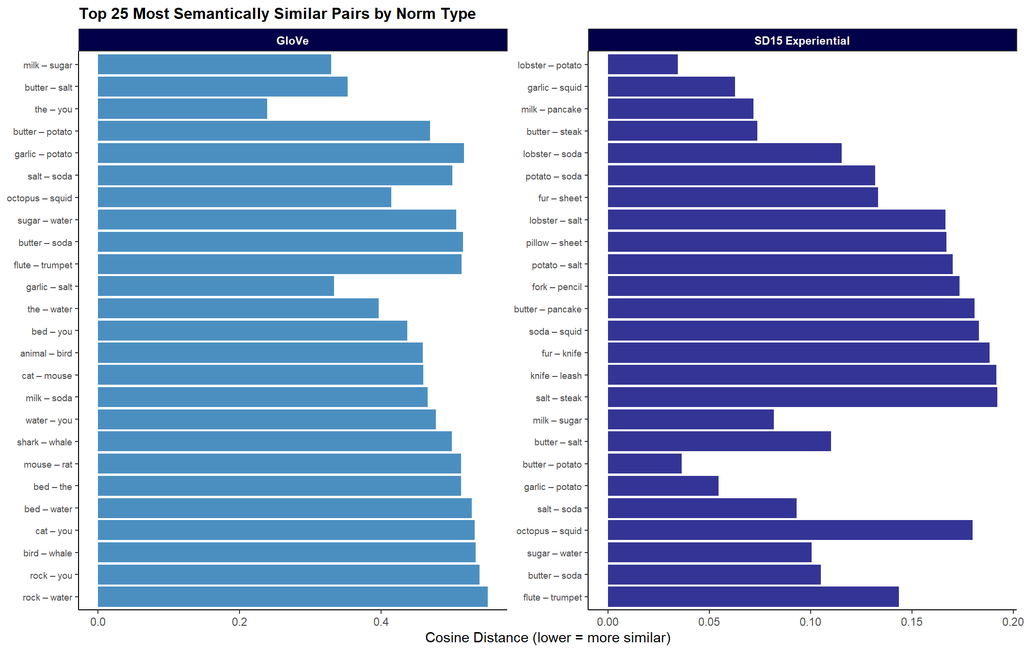

```r
# Most semantically similar pairs by each norm

closest_glove <- all_dists %>%
  arrange(glove_distance) %>% slice_head(n = 25) %>%
  mutate(pair = paste(word1, "–", word2), norm = "GloVe", dist = glove_distance)

closest_sd15 <- all_dists %>%
  arrange(sd15_distance) %>% slice_head(n = 25) %>%
  mutate(pair = paste(word1, "–", word2), norm = "SD15 Experiential", dist = sd15_distance)

top_pairs <- bind_rows(closest_glove, closest_sd15)

ggplot(top_pairs, aes(x = reorder(pair, -dist), y = dist, fill = norm)) +
  geom_col(alpha = 0.85) +
  coord_flip() +
  facet_wrap(~norm, scales = "free") +
  scale_fill_manual(values = c("GloVe" = "#2C7BB6",
                               "SD15 Experiential" = "#111184")) +
  labs(
    title = "Top 25 Most Semantically Similar Pairs by Norm Type",
    x = NULL, y = "Cosine Distance (lower = more similar)"
  ) +
  jamie.theme +
  theme(legend.position = "none",
        axis.text.y      = element_text(size = 7),
        strip.background = element_rect(fill = "#010048"),
        strip.text       = element_text(colour = "white", face = "bold"),
        plot.title       = element_text(face = "bold", size = 12))
```

# What Does It All Mean?

The Pearson r = 0.342 and Spearman rho = 0.346 between GloVe and SD15 distances suggest moderate overlap, accounting for roughly 12% of shared variance. These two metrics are measuring related but meaningfully different aspects of semantic similarity, and that gap is the whole point of this comparison.

**GloVe** is purely distributional. It assigns similarity based on where a word appears in text, which documents, which sentences, which neighboring words. The GloVe distribution reflects this: mean of 0.806, SD of 0.141, range from 0.239 to 1.103, and a left skew of -1.0. Most random word pairs land in the mid-to-high distance range. GloVe only pulls words close together when they genuinely and repeatedly co-occur in similar contexts. The narrow SD tells me GloVe is not very sensitive to the full range of possible semantic relationships. It lives in a compressed slice of distance space.

**SD15** is built from human perceptual and sensorimotor ratings across dimensions including auditory, gustatory, haptic, visual, olfactory, and interoceptive experience. The SD15 distribution is much wider: mean of 0.726, SD of 0.315, range from 0.035 to 1.628, and near-zero skew (-0.039). Human experiential space has more dynamic range than corpus space. Words can be nearly identical in sensory profile (lobster-potato at 0.035) or completely alien to each other (bed-the at 1.628), and the rating system captures that full spread.

**Why I deduplicated and removed identical pairs:** I did not want dog-dog inflating similarity scores, and I did not want apple-dog and dog-apple counted as separate observations. The sort-and-distinct approach ensures every pair appears exactly once in canonical order, which is important for large clean sampling.

**Why cosine distance instead of cosine similarity:** Cosine similarity runs from -1 to 1, which is awkward to interpret. Subtracting from 1 gives a distance metric bounded from 0 to 2, where 0 means the two word vectors are identical and 2 means maximally far apart. This makes the numbers more intuitive to discuss and compare across metrics.

**The divergence table** shows where GloVe and SD15 disagree most. The-you has a GloVe distance of 0.239 but an SD15 distance of 1.503. “The” and “you” appear together constantly in text so GloVe marks them as close. But “the” has no sensory or perceptual profile whatsoever across the SD15 dimensions, while “you” carries social and interoceptive significance GloVe is picking up on syntactic co-occurrence, not meaning. The same pattern holds for bed-the (GloVe: 0.513, SD15: 1.628) and fur-the (GloVe: 0.746, SD15: 1.419). Function words like “the” artificially inflate GloVe similarity with nearly everything because they are present in virtually every document.

The opposite pattern is interesting. Lobster-soda has a GloVe distance of 0.941 but an SD15 distance of 0.115. Garlic-squid is GloVe: 0.812, SD15: 0.063. Milk-pancake is GloVe: 0.789, SD15: 0.072. GloVe marks these pairs as distant because they rarely co-occur in text. SD15 marks them as nearly identical because they share strong gustatory, olfactory, and haptic signatures. Lobster and soda are both consumable, mouth-relevant objects. Garlic and squid share intense smell and taste profiles. Milk and pancake activate overlapping sensorimotor representations grounded in food preparation and eating. None of this is recoverable from co-occurrence statistics.

**The takeaway** is that GloVe captures abstract, propositional, and syntactic relationships in language. SD15 captures the embodied, grounded structure of meaning built from human sensory experience. The r = 0.342 tells me they share enough common signal to be measuring something real in the same direction, but they diverge enough that they are not interchangeable. For cognitive and psycholinguistic research where the goal is to model how meaning is represented in the human mind, SD15 is the more ecologically valid metric. Using both together gives better coverage than either alone.